# timeSeries_Demo

2024-03-10

Some codes and data were borrowed from Dr. Bhaskaran et al https://github.com/gasparrini/2013_bhaskaran_IJE_codedata/blob/master/londondataset2002_2006.dta

*Time series regression studies in environmental epidemiology* Bhaskaran, Gasparrini, Hajat, Smeeth and Armstrong International Journal of Epidemiology - 2013 http://www.ag-myresearch.com/2013_bhaskaran_ije.shtml

Extra lines were inserted to make the codes easier to follow and illustrate the assumptions of time-series data more explicit

### Install or load libraries

```r
# remove all variables to clean the environment
rm(list = ls())

# First install the package - !! Once installed, remove the installation commande below or comment out by #, as there is no need to install the same lib again and again, all it takes is to use library() command to load installed library.
#install.packages("foreign")
#install.packages("dlnm")
#install.packages("tsModel")
#install.packages("Epi")
#install.packages("tidyverse")
#install.packages("imputeTS")
#install.packages("splines")
#install.packages("haven")


# laod the package installed if installed already
library(foreign)
library(tidyverse)
library(dlnm)
library(Epi) # if needed for fancy result display
library(tsModel)
library(imputeTS) # for assignment, not really neededfor this demo
library(splines)
library(haven) # needed to load Stata DTA file format below
```

## Describe data

```r
# Get file directly from web URL,
# Download data from:    https://github.com/gasparrini/2013_bhaskaran_IJE_codedata/blob/master/londondataset2002_2006.dta
data <- read_dta("londondataset2002_2006_bhaskaran_IJE.dta")
#write.csv(data, "londondataset2002_2006_bhaskaran_IJE.csv")

# SET THE DEFAULT ACTION FOR MISSING DATA TO na.exclude
# (MISSING EXCLUDED IN ESTIMATION BUT RE-INSERTED IN PREDICTION/RESIDUALS)
options(na.action="na.exclude")

# Display data, only first 5 lines
head(data, 5)
```

```
## # A tibble: 5 × 5
##   date       ozone temperature relative_humidity numdeaths
##   <date>     <dbl>       <dbl>             <dbl>     <dbl>
## 1 2002-01-01  4.59     -0.225               75.7       199
## 2 2002-01-02  4.88      0.0875              77.5       231
## 3 2002-01-03  4.71      0.850               81.3       210
## 4 2002-01-04  4.14      0.538               85.4       203
## 5 2002-01-05  2.01      4.25                93.5       224
```

```r
# Data structure
str(data)
```

```
## tibble [1,826 × 5] (S3: tbl_df/tbl/data.frame)
##  $ date             : Date[1:1826], format: "2002-01-01" "2002-01-02" ...
##  $ ozone            : num [1:1826] 4.59 4.88 4.71 4.14 2.01 ...
##   ..- attr(*, "label")= chr "Ozone level in ug/m3"
##   ..- attr(*, "format.stata")= chr "%9.0g"
##  $ temperature      : num [1:1826] -0.225 0.0875 0.85 0.5375 4.25 ...
##   ..- attr(*, "label")= chr "Temperature in deg C"
##   ..- attr(*, "format.stata")= chr "%9.0g"
##  $ relative_humidity: num [1:1826] 75.7 77.5 81.3 85.4 93.5 ...
##   ..- attr(*, "label")= chr "Relative humidity in %"
##   ..- attr(*, "format.stata")= chr "%9.0g"
##  $ numdeaths        : num [1:1826] 199 231 210 203 224 198 180 188 168 194 ...
##   ..- attr(*, "label")= chr "N deaths"
##   ..- attr(*, "format.stata")= chr "%9.0g"
```

```r
# SUMMARY
summary(data)
```

```
##       date                ozone          temperature     relative_humidity
##  Min.   :2002-01-01   Min.   :  1.182   Min.   :-1.401   Min.   :31.23
##  1st Qu.:2003-04-02   1st Qu.: 21.091   1st Qu.: 7.506   1st Qu.:58.69
##  Median :2004-07-01   Median : 34.922   Median :11.473   Median :69.61
##  Mean   :2004-07-01   Mean   : 34.772   Mean   :11.720   Mean   :69.10
##  3rd Qu.:2005-09-30   3rd Qu.: 46.725   3rd Qu.:16.198   3rd Qu.:80.36
##  Max.   :2006-12-31   Max.   :119.246   Max.   :28.175   Max.   :98.86
##    numdeaths
##  Min.   : 99.0
##  1st Qu.:135.0
##  Median :148.0
##  Mean   :149.5
##  3rd Qu.:162.0
##  Max.   :280.0
```

```r
# CORRELATIONS across each variables
cor(data[,2:5])
```

```
##                        ozone temperature relative_humidity  numdeaths
## ozone              1.0000000   0.4560300        -0.5269955 -0.1233181
## temperature        0.4560300   1.0000000        -0.4442078 -0.4037833
## relative_humidity -0.5269955  -0.4442078         1.0000000  0.2157940
## numdeaths         -0.1233181  -0.4037833         0.2157940  1.0000000
```

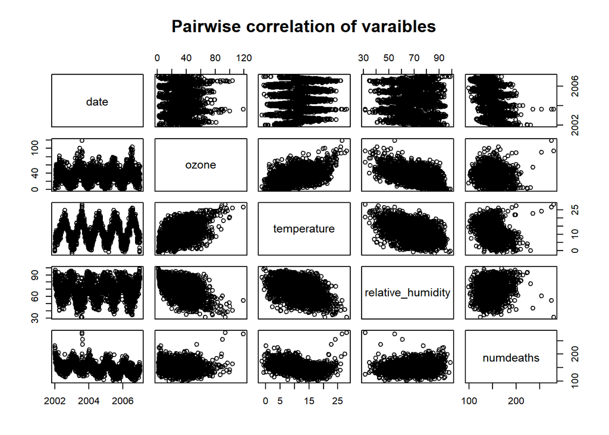

```r
# plot correlation - takes bit of time of see this plot
pairs(data, main = "Pairwise correlation of varaibles")
```

```r
data$numdeaths <- log(data$numdeaths)
```

### Make plots for the several time-seriesin the dataset, namely exposure (O3), outcome (death count), temperature, and humidity - the latter two maybe control variables

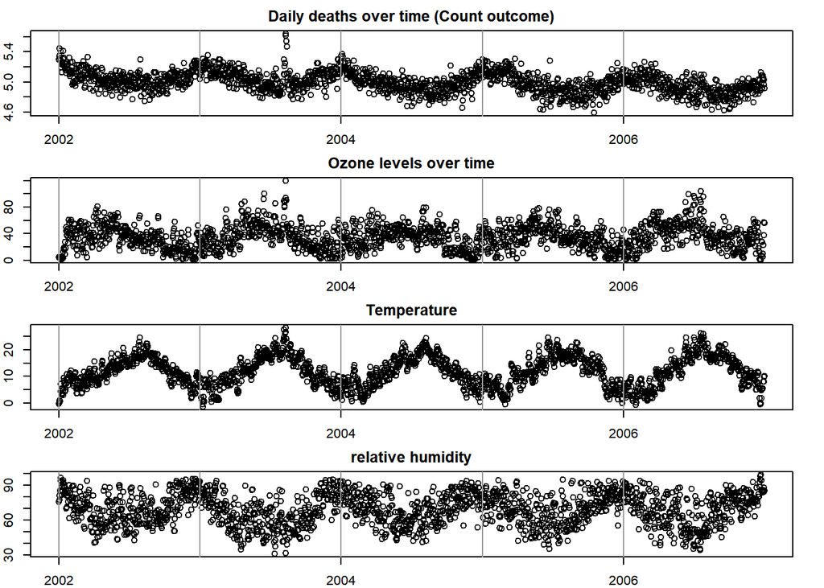

```r
# SET THE PLOTTING PARAMETERS FOR THE PLOT (SEE ?par)
# this allow making two pltos in one window
par(mar=c(2, 2, 2, 2), mex=0.8, mfrow=c(2,1))  # Sets smaller margins
oldpar <- par(no.readonly=TRUE)
par(mex=0.8,mfrow=c(4,1))


# SUB-PLOT FOR DAILY DEATHS, WITH VERTICAL LINES DEFINING YEARS
plot(data$date,data$numdeaths,main="Daily deaths over time (Count outcome)",
     ylab="Daily number of deaths", xlab = "week")
## add year line vertical
abline(v=data$date[grep("-01-01",data$date)],col=grey(0.6),lty=1)


# THE SAME FOR OZONE LEVELS
plot(data$date,data$ozone,main="Ozone levels over time",
     ylab="Daily mean ozone level (ug/m3)",xlab="Date")
abline(v=data$date[grep("-01-01",data$date)],col=grey(0.6))
## add year line vertical
abline(v=data$date[grep("-01-01",data$date)],col=grey(0.6),lty=1)


# Temperature
plot(data$date,data$temperature,main="Temperature",
     ylab="Daily temp",xlab="Date")
abline(v=data$date[grep("-01-01",data$date)],col=grey(0.6))


# Humidity
plot(data$date,data$relative_humidity,main="relative humidity",
     ylab="Daily humidity",xlab="Date")
abline(v=data$date[grep("-01-01",data$date)],col=grey(0.6))
```

## Demonstration of time-series decomposition

#### Decompose into periodic (seasonal) patterns and a long-term trend, plus random error

Y axis represents death count. The last (random) component is ideally stationary and can be used for exposure-outcome anlaysis. However, in the demo regression analysis below, we will not use this decomposition and instead use typical epidemologic ‘confounder control’ approach to adjust for the seasonal trend (but how do we accout for the downward trend?).

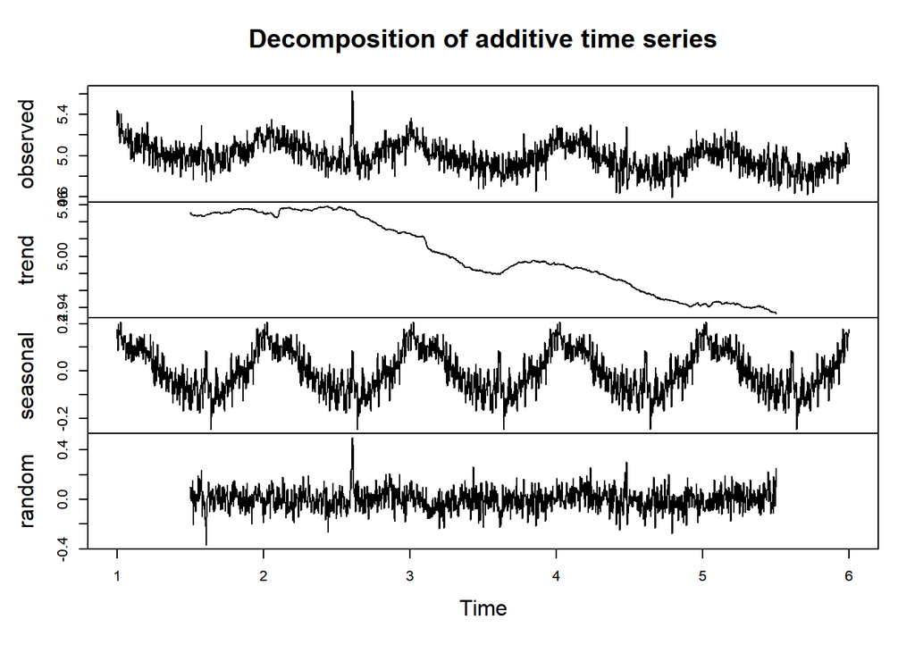

```r
### Plot to decompose time-series - need to conver to a data structure called "ts"
tsData <- ts(data$numdeaths, frequency = 365)
tsDataDecomposed <- decompose(tsData)
plot(tsDataDecomposed)
```

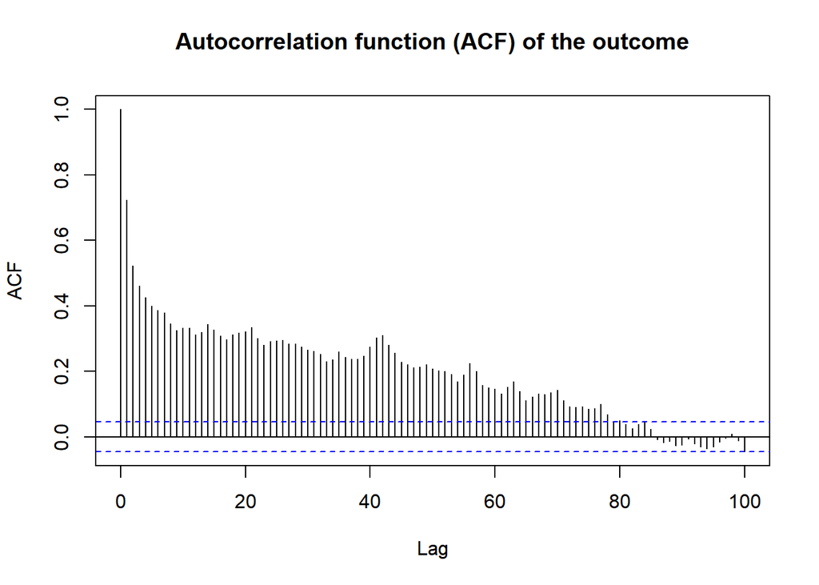

```r
acf(data$ozone, main = "Autocorrelation function (ACF) of the outcome", lag.max = 100)
```

## How much autocorrelation in the random componetn after de-trending?, check with ACF

Much better, but still a lot of correlation - we will try to replicate this decomposition using regression in the demo below.

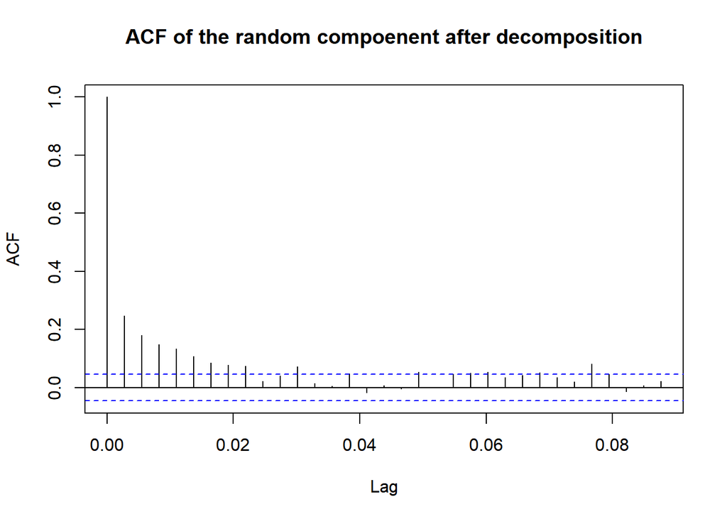

```r
acf(tsDataDecomposed$random, na.action = na.pass, main = "ACF of the random compoenent after decomposition")
```

## Differentiation

### Rather than the decomposition above, differeniation (taking time-shifted difference), that is,

$$y_{dt} = y_t - y_{t-1}$$
as the outcome will also remove trends to a large extent (this is called first order difference).

How much autocorrelation in our 1st order differenciated outcome??, check with ACF ### Differentiation is not shown in the class and not needed for the assignment

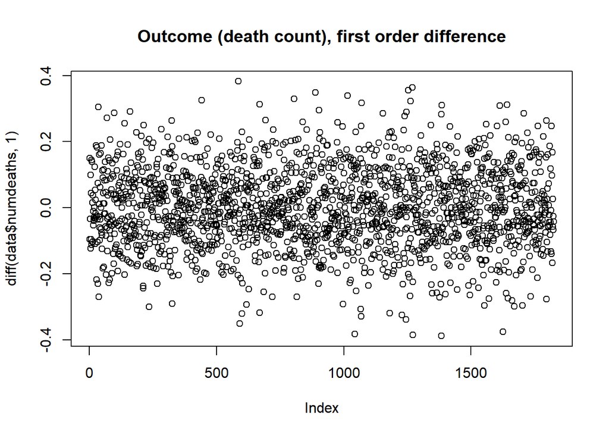

```r
  plot(diff(data$numdeaths, 1), main = "Outcome (death count), first order difference")
```

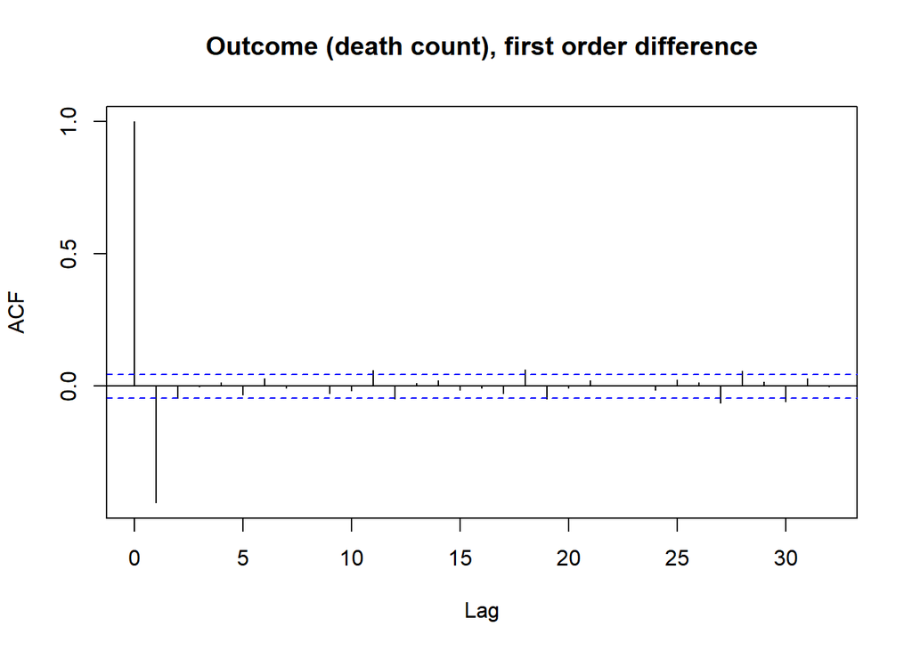

```r
  acf(diff(data$numdeaths, 1), main = "Outcome (death count), first order difference")
```

# Demo codes for assignment

We will use the London dataset loaded above for a demo.

```r
#################
# SCALE EXPOSURE
#################
summary(data$ozone)
```

```
##    Min. 1st Qu.  Median    Mean 3rd Qu.    Max.
##   1.182  21.091  34.922  34.772  46.725 119.246
```

```r
data$ozone10 <- data$ozone/10

summary(data$ozone10) # double check scaled or not , new variable ozone10
```

```
##    Min. 1st Qu.  Median    Mean 3rd Qu.    Max.
##  0.1182  2.1091  3.4922  3.4772  4.6725 11.9246
```

#### Now, 1 unit increase of the ozone exposure variable corresponds to a $10ug/m^3$ increase.

## Linear regression-based analysis for log-transformed count data

## Model 1 - unadjusted

Lets estimate the association between ozone and death count ### No confounding adjustment, just a crude association between O3 and death count The outcome is count, but that is not too easy to model using transitional time-sereis approach. Large count with Poisson distribution can be approximated by normal distribution (recall intro stats), but that does not mean we can use regular linear regression with normal (continuous) outcome. **WHY?**.  
So, we will natural log-transform the count outcome, which will force the estimated regression parameters to be positive (when exponentiated).

$$y_t = log(countDeath_t)$$
$$y_t = \beta_0 + \beta_{ozone} X_t +
\epsilon_t$$
$\beta_0$ is the intercept term.
$\beta_{ozone}$ is regression coefficient representing the association between ozone and *natural log-transformed* mortality count. $\epsilon_t \sim Normal(0, \sigma^2)$
This is called “white noise” i.e., residual time-series with zero mean and zero autocorrelation.
We will remove $log(population)$ offset, as the underlying population is assumed to be constant over time (open cohort), though this offset will be very critical in spatial analysis next week.

Note that the coefficient below for this analysis is negative sign - **Ozone is protective of death. Is this a valid result**?

*Be sure* you can make the proper interpretation of $\beta_{ozone}$, as $y_t$ is natural log-transformed.

```r
################################################################################
# ESTIMATING OZONE-MORTALITY ASSOCIATION
# (CONTROLLING FOR CONFOUNDERS)
############################################

# COMPARE THE RR (AND CI)
# (COMPUTED WITH THE FUNCTION ci.lin IN PACKAGE Epi, TO BE INSTALLED AND LOADED)

# UNADJUSTED MODEL, only including Ozone
model1 <- lm(numdeaths ~ ozone,data)
summary(model1)
```

```
##
## Call:
## lm(formula = numdeaths ~ ozone, data = data)
##
## Residuals:
##      Min       1Q   Median       3Q      Max
## -0.42103 -0.08968 -0.00064  0.09019  0.69970
##
## Coefficients:
##               Estimate Std. Error t value Pr(>|t|)
## (Intercept)  5.0313727  0.0067787 742.232  < 2e-16 ***
## ozone       -0.0009585  0.0001725  -5.556 3.17e-08 ***
## ---
## Signif. codes:  0 '***' 0.001 '**' 0.01 '*' 0.05 '.' 0.1 ' ' 1
##
## Residual standard error: 0.1349 on 1824 degrees of freedom
## Multiple R-squared:  0.01664,    Adjusted R-squared:  0.0161
## F-statistic: 30.87 on 1 and 1824 DF,  p-value: 3.171e-08
```

### Impact of ozone exposure on the outcome

Rate Ratio indicates the rate of death (# number death count divided by person-time) in response to one unit increase of ozone. The number look deceivingly small, because it is one unit increase (see the range of ozone in y axis) of ozone, which is tiny, though it will be a substantial count, if we are to talk about the 10-unit increase.  
See the column for the RR `exp(Est.)`..the ratio is leass than 1.0, so ozone looks protective of dealth, when confounding is not accounted for

```r
ci.lin(model1,subset="ozone",Exp=T) %>%  round(digit = 4)
```

```
##       Estimate StdErr       z P exp(Est.)   2.5%  97.5%
## ozone   -0.001  2e-04 -5.5558 0     0.999 0.9987 0.9994
```

### ACF

Residual shows strong autocorrelation. **The model is not valid.**

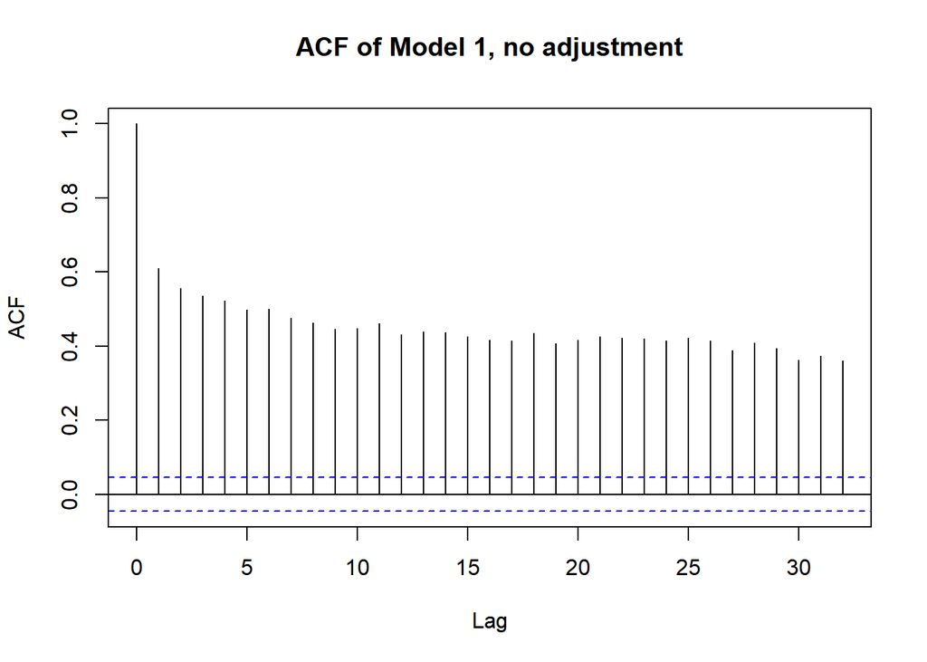

```r
acf(residuals(model1, type = "response"), main = "ACF of Model 1, no adjustment")
```

#### Aside from autcorrelation, we will also check the starndard assumptions of linear regression.

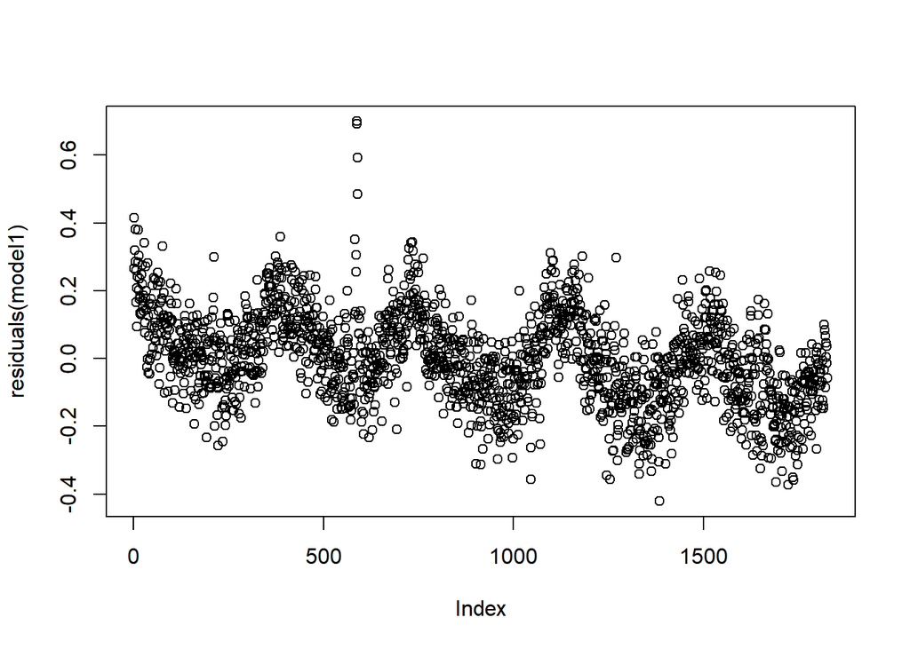

```r
plot(residuals(model1))
```

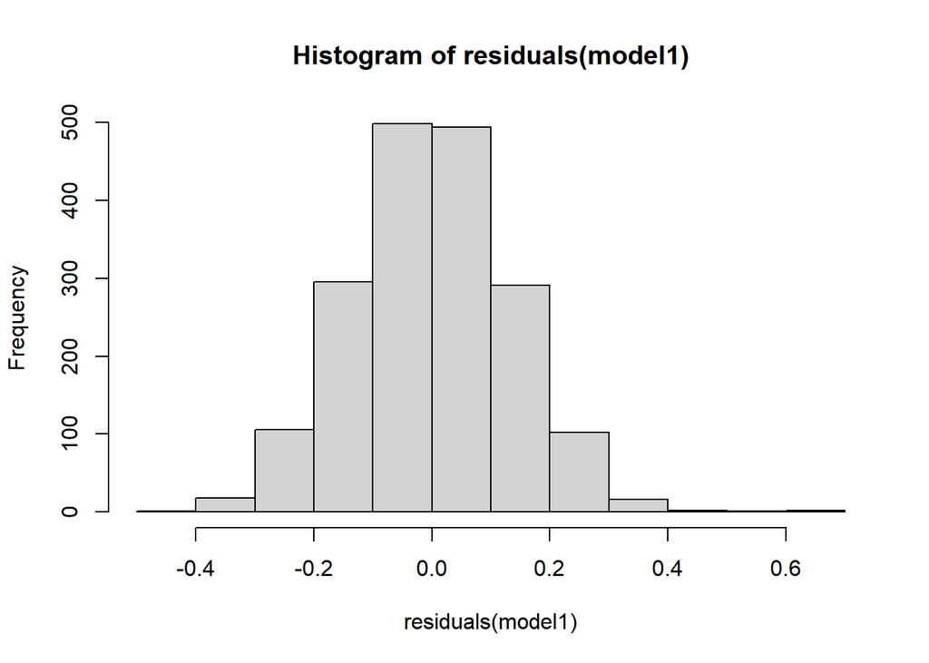

```r
hist(residuals(model1))
```

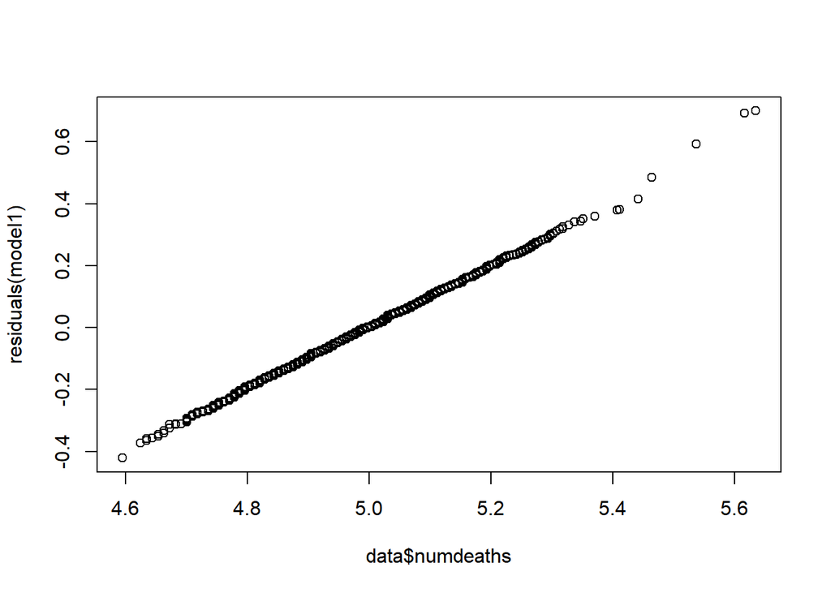

```r
qqplot(data$numdeaths, residuals(model1))
```

## Model 2

### Lets control for seasonality as a confounder in our model equation above

we will use regression techniques to control seasonality buy adding a variable that have wave shape through a data transformation involving sine and cosine function:

$$y_t = \beta_0 + \beta_{ozone} x_t +
S_t + \delta t + \epsilon_t,$$
$$S_t
= \gamma_{cos} cos(2kt\pi) + \gamma_{sin} sin(2kt\pi) ,$$
where
$$k = 365.25, \pi = 3.141593$$
$\beta_0$ is the intercept term
$\beta_{ozone}$ is a regression coefficient representing the association between ozone and mortality count
$\delta$ is a coefficient attempting to capture the linear time trend (that appear to show downward trends in the outcome time-series) using a variable denoted $t$ (integer). **Check how the varaible $t$** looks like in the data. $\gamma_{cos}$ and $\gamma_{sin}$ are regression terms for the wave funcations.

```r
#####################################
# OPTION 2: PERIODIC FUNCTIONS MODEL
# (FOURIER TERMS)
#####################################
# GENERATE FOURIER TERMS
# (USE FUNCTION harmonic, IN PACKAGE tsModel TO BE INSTALLED AND THEN LOADED)
# 4 SINE-COSINE PAIRS REPRESENTING DIFFERENT HARMONICS WITH PERIOD 1 YEAR

data$time <- seq(nrow(data))
fourier <- harmonic(data$time,nfreq=4,period=365.25)

# FIT A POISSON MODEL FOURIER TERMS + LINEAR TERM FOR TREND
# (USE OF quasipoisson FAMILY FOR SCALING THE STANDARD ERRORS)
model2 <- lm(numdeaths ~ ozone + fourier + time,data)

# COMPUTE FITTED NUMBER OF DEATHS FROM THIS MODEL
pred2 <- predict(model2)
```

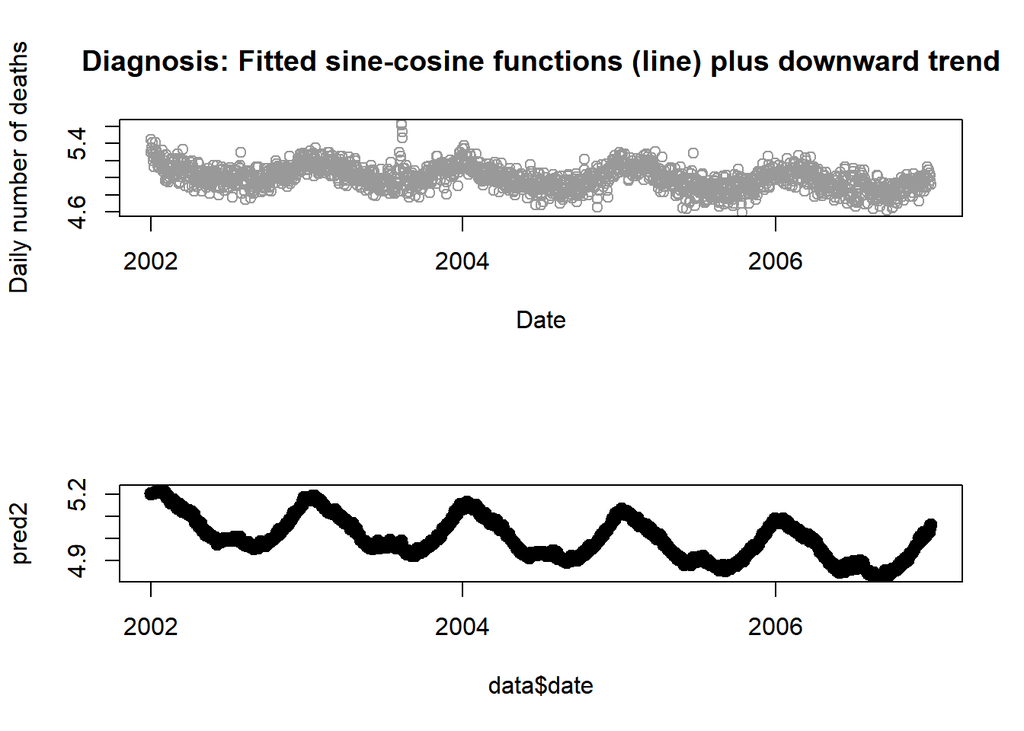

```r
#############
# FIGURE 2B in the manuscript
#############
par(mfrow= c(2,1))
plot(data$date,data$numdeaths ,col=grey(0.6),
     main="Diagnosis: Fitted sine-cosine functions (line) plus downward trend",ylab="Daily number of deaths",
     xlab="Date")
plot(data$date,pred2,lwd=2)
```

### Autocorrelation: Lets diagnose the model that controlled for seasonality and trend.

Compare the strength of autocorrelation (undesirable feature to be removed) between this plot and the plot without seasonality correction above. It is not great, but much better than the results from step 1 above (no control for seasonality)

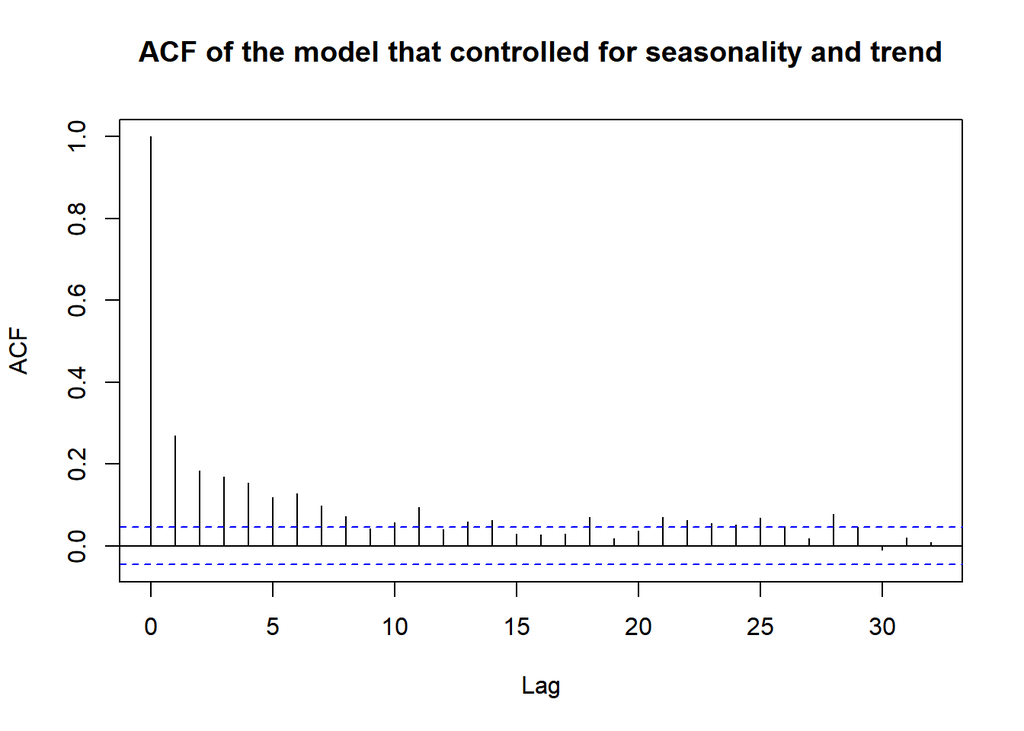

```r
#############
# Diagnosis of Model 2
#############
acf(residuals(model2), main = "ACF of the model that controlled for seasonality and trend")
```

Rate Ratio, rate of death (# number of person-time) in response to one unit increase of ozone Now, the RR of ozone is positive, (or greater than 1.0 when exponentiated), meaning that ozone is associated with death after controlling for period effects

```r
# Formatted table, only visible in HTML output
ci.lin(model2,subset="ozone") %>%  round(digit = 4)
```

```
##       Estimate StdErr      z     P  2.5% 97.5%
## ozone    5e-04  2e-04 3.4637 5e-04 2e-04 8e-04
```

## Model 3, Controlling for a categorical variable

Now control for temperature as well. For simplicity, temperature will be added as a categories variable, but spline is probably a better approach (see step 4 below to control temperature)

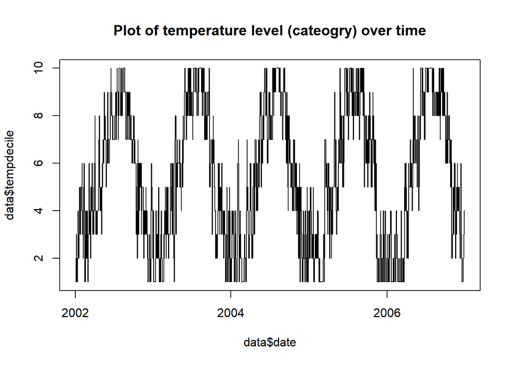

```r
# (TEMPERATURE MODELLED WITH CATEGORICAL VARIABLES FOR DECILES)
# (MORE SOPHISTICATED APPROACHES ARE AVAILABLE - SEE ARMSTRONG EPIDEMIOLOGY 2006)

cutoffs <- quantile(data$temperature,probs=0:10/10)
data$tempdecile <- cut(data$temperature,breaks=cutoffs,include.lowest=TRUE)

plot(y=data$tempdecile, x = data$date, type = "l", main = "Plot of temperature level (cateogry) over time")
```

```r
# CONTROLLING FOR TEMPERATURE, plus ozone and seasonality
model3 <- lm(numdeaths ~ ozone + fourier + time + tempdecile, data)
```

Lets check RR

```r
ci.lin(model3,subset="ozone") %>%  round(digit = 4)
```

```
##       Estimate StdErr      z      P   2.5% 97.5%
## ozone    2e-04  2e-04 1.3231 0.1858 -1e-04 5e-04
```

Does not look too much better than step 2, controlling for season only …And ACF (autocorrelation) after accounting for temperature

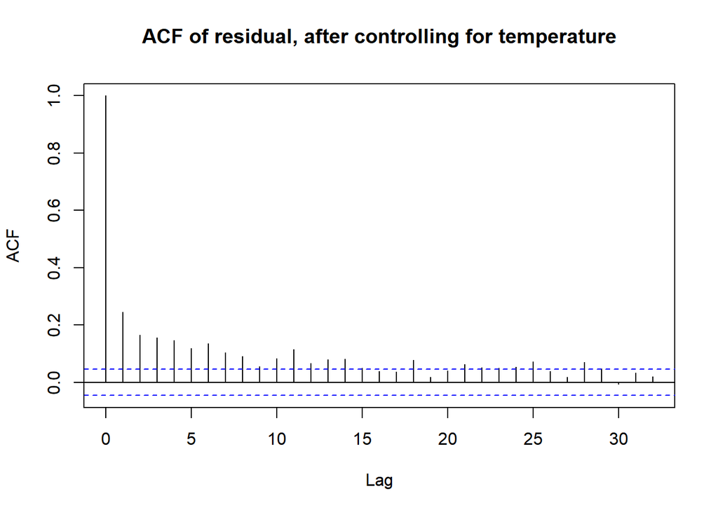

```r
acf(residuals(model3), main = "ACF of residual, after controlling for temperature")
```

### Additional info (not need to show in the assignment), coefficients of temperature (not so imporant imapct on death, likely because already adjusted by seasonality )

```r
summary(model3)
```

```
##
## Call:
## lm(formula = numdeaths ~ ozone + fourier + time + tempdecile,
##     data = data)
##
## Residuals:
##      Min       1Q   Median       3Q      Max
## -0.31694 -0.06295 -0.00078  0.06317  0.63111
##
## Coefficients:
##                         Estimate Std. Error t value Pr(>|t|)
## (Intercept)            5.069e+00  1.085e-02 467.167  < 2e-16 ***
## ozone                  2.149e-04  1.624e-04   1.323  0.18596
## fourier1               5.655e-02  4.661e-03  12.133  < 2e-16 ***
## fourier2               4.769e-03  3.833e-03   1.244  0.21356
## fourier3              -4.898e-03  3.428e-03  -1.429  0.15320
## fourier4               5.204e-03  3.321e-03   1.567  0.11726
## fourier5               1.171e-01  6.997e-03  16.733  < 2e-16 ***
## fourier6               1.614e-02  3.572e-03   4.519 6.63e-06 ***
## fourier7               3.376e-03  3.241e-03   1.042  0.29769
## fourier8               9.703e-03  3.239e-03   2.995  0.00278 **
## time                  -9.502e-05  4.512e-06 -21.061  < 2e-16 ***
## tempdecile(4,6.44]    -6.071e-03  1.030e-02  -0.590  0.55554
## tempdecile(6.44,8.27] -2.364e-02  1.064e-02  -2.222  0.02640 *
## tempdecile(8.27,10]   -7.016e-03  1.102e-02  -0.637  0.52423
## tempdecile(10,11.5]   -5.174e-04  1.200e-02  -0.043  0.96562
## tempdecile(11.5,13.3] -4.534e-03  1.305e-02  -0.347  0.72829
## tempdecile(13.3,15.3]  8.116e-03  1.438e-02   0.564  0.57253
## tempdecile(15.3,17]    1.083e-02  1.547e-02   0.700  0.48412
## tempdecile(17,18.9]    1.643e-02  1.628e-02   1.010  0.31284
## tempdecile(18.9,28.2]  8.932e-02  1.739e-02   5.137 3.09e-07 ***
## ---
## Signif. codes:  0 '***' 0.001 '**' 0.01 '*' 0.05 '.' 0.1 ' ' 1
##
## Residual standard error: 0.09741 on 1806 degrees of freedom
## Multiple R-squared:  0.492,  Adjusted R-squared:  0.4867
## F-statistic: 92.06 on 19 and 1806 DF,  p-value: < 2.2e-16
```

## Model 4. Constrained distributed lag model (DLM)

#### One for exposure (Ozone), and the other for the temperature confounder adjusted above

#### Now, add a series of *time-lag* to the exposure (this is called distributed lag model).

This model allow the expsoure today to impact death count tomorrow, day after tomorrow..and so on using a distributed lag model.  
Additionally, we will add lag to temperature too for a better adjustment.

We will give 7 days lags (this is something you have to decide before analysis from literature, not always trivial). If you actually want to learn the length of lag from data rather than literature, you would need transfer function (not discussedin the class).

Refer to the lecture slides as to why we do not use a series of regression coefficients
$$y_t = \beta_0 + \beta_{ozone1} X_1 +
\beta_{ozone2} X_2 + \beta_{ozone3} X_3 + ... + \beta_{ozone7} X_7 +
\epsilon_t,$$
and instead prefer to use a constrained non-linear function below
$$y_t = \beta_0 + f(x_{t};\beta) +
\epsilon_t,$$
where $x_t$ is the exposure, and $\beta$ is the vector of coefficient for each lag.

```r
# IN PARTICULAR, THE FUNCTION crossbasis PRODUCES THE TRANSFORMATION FOR
#   SPECIFIC LAG STRUCTURES AND OPTIONALLY FOR NON-LINEARITY
# THE FUNCTION crosspred INSTEAD PREDICTS ESTIMATED EFFECTS

# PRODUCE THE CROSS-BASIS FOR TEMPERATURE
# AS ABOVE, BUT WITH STRATA DEFINED BY INTERNAL CUT-OFFS
cbtempunc <- crossbasis(data$temperature,lag=c(0,7),
                        argvar=list(fun="strata",
                                    breaks=cutoffs[2:10]),
                        arglag=list(fun="integer"))
```

```r
####################################
# CONSTRAINED (LAG-STRATIFIED) DLM - Distibuted Lag Model
####################################

# PRODUCE A DIFFERENT CROSS-BASIS FOR OZONE
# USE STRATA FOR LAG STRUCTURE, WITH CUT-OFFS DEFINING RIGHT-OPEN INTERVALS
cbo3constr <- crossbasis(data$ozone,lag=c(0,7),
                         argvar=list(fun="lin"),
                         arglag=list(fun="strata",breaks=c(1,3)))
```

Fitting the distributed lag model and generating estiamted lag effect

```r
model4 <- lm(numdeaths ~ cbo3constr + cbtempunc + fourier + date ,data)


# Generate (predict) lag patterns for visualization below
pred4_Ozone <- crosspred(cbo3constr,model4,at=10)
pred4_Temp <- crosspred(cbtempunc,model4,at=10)
```

### Lets plot the lagged impact of ozone on mortality counts over days from the distributed lag effect above.

The plot shows the effect of Ozone on day $t$ on the same day ($t$), next day ($t+1$), day after ($t+3 ... t+7$)…so that we will allow ozone to influence mortality as a carryover effect over days, even after ozone level goes down.

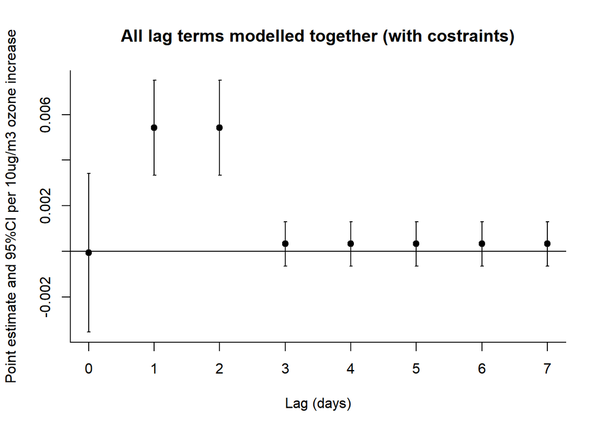

```r
#############
# FIGURE 4C
#############

plot(pred4_Ozone,var=10,type="p",ci="bars",col=1,pch=19,
     main="All lag terms modelled together (with costraints)",xlab="Lag (days)",
     ylab="Point estimate and 95%CI per 10ug/m3 ozone increase")
```

### Impact of temperature (onfounder) - Compare the scale in the y-axis.

The reduced RR

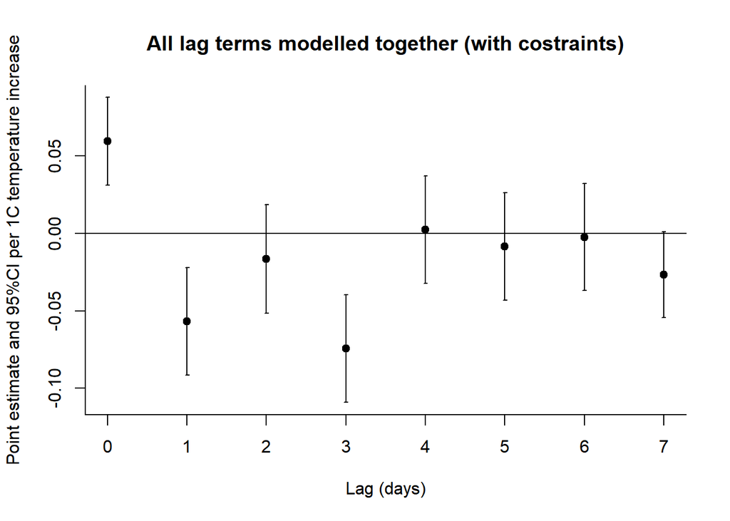

```r
#############
# FIGURE 4C
#############

plot(pred4_Temp,var=10,type="p",ci="bars",col=1,pch=19,
     main="All lag terms modelled together (with costraints)",xlab="Lag (days)",
     ylab="Point estimate and 95%CI per 1C temperature increase")
```

## Autocurrelation for Model 4

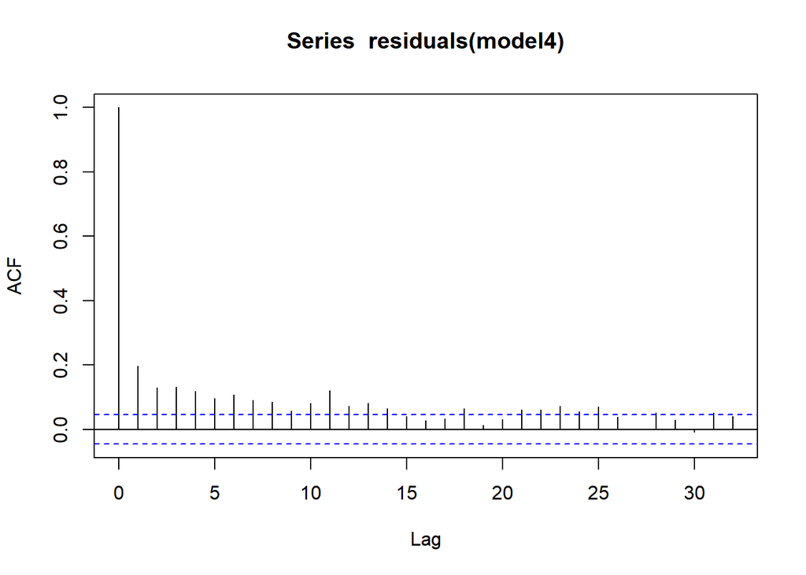

```r
acf(residuals(model4), na.action = na.omit)
```

## Model 5 - AR(1) model

## Not really needed the assignmenbt, but give a better result

### Finally, lets assume that death count in previous day is confoudning the count of death today i.e., associated with the exposure ie.g., O3, and death count in next day. In other words, we will control for the lagged outcome of 1 day (previous day) as a confounder.

```r
# RUN THE MODEL AND OBTAIN PREDICTIONS FOR OZONE LEVEL 10ug/m3
data$y_lag <- NA
data$y_lag  <-  lag(data$numdeaths)


model5 <- glm(numdeaths ~ cbo3constr + cbtempunc + fourier + date + y_lag ,data,family=quasipoisson)
pred5 <- crosspred(cbo3constr,model5,at=10)
```

## ACF of AR(1) model

Now check ACF after controlling for the count of death from previous day  
IT still has issue in autcorrelation.

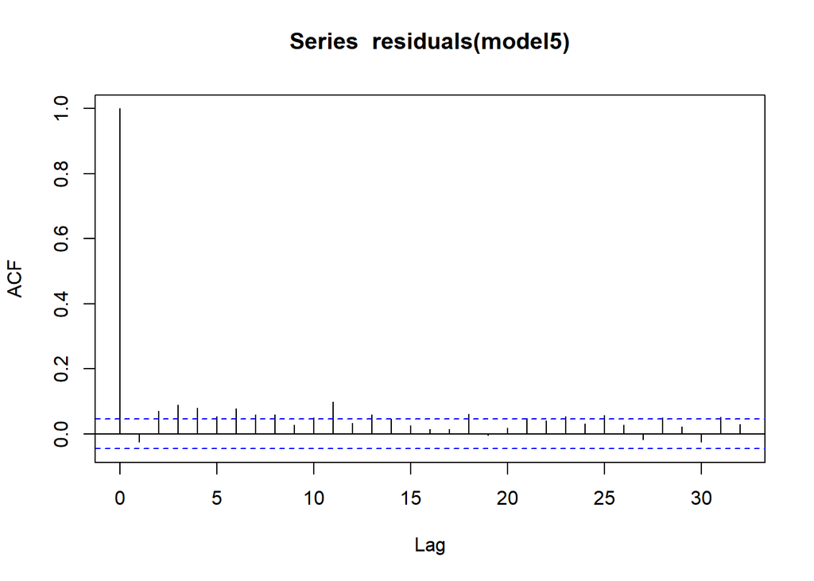

```r
acf(residuals(model5), na.action = na.omit)
```

# Model 6, Differenciation of Y variable makes

### Optional info, not part of the assignment.

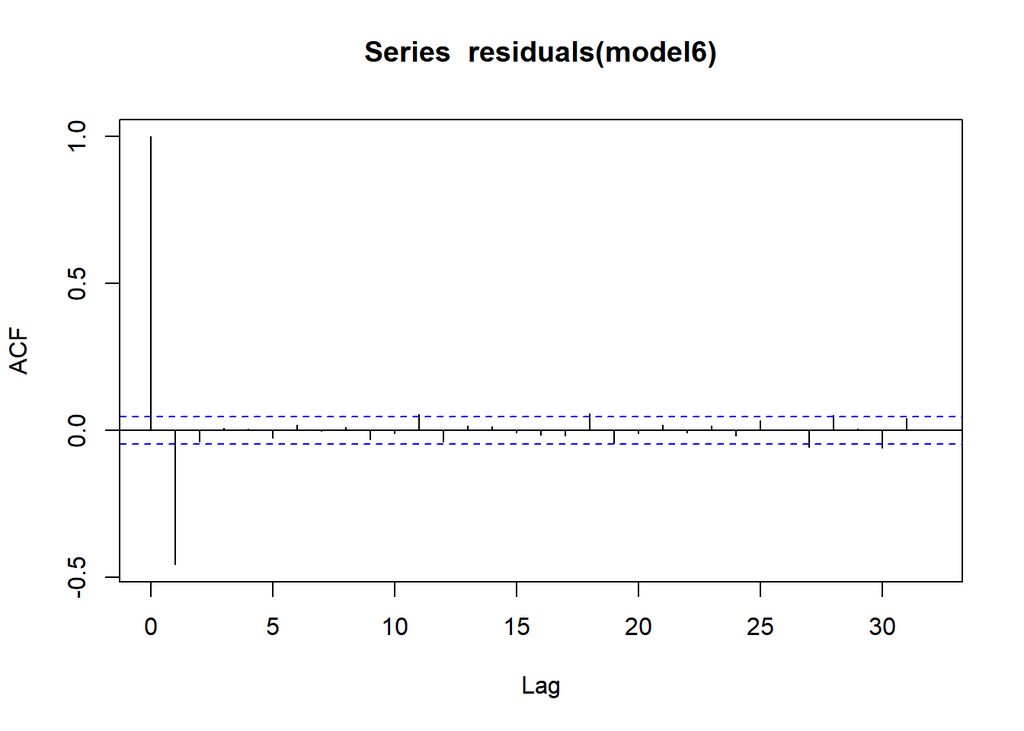

```r
cbtempunc <- crossbasis(data$temperature,lag=c(0,7),
                        argvar=list(fun="strata",
                                    breaks=cutoffs[2:10]),
                        arglag=list(fun="integer"))

cbo3constr <- crossbasis(data$ozone,lag=c(0,7),
                         argvar=list(fun="lin"),
                         arglag=list(fun="strata",breaks=c(1,3)))


data <- data  %>% mutate(diff_y = numdeaths - lag(numdeaths))



model6<- lm(diff_y ~ cbo3constr + cbtempunc, data)
acf(residuals(model6), na.action = na.pass)
```

[figure not shown]

```r
pred4_Ozone <- crosspred(cbo3constr,model4,at=10)
pred4_Temp <- crosspred(cbtempunc,model4,at=10)


plot(pred4_Temp,var=10,type="p",ci="bars",col=1,pch=19,
     main="All lag terms modelled together (with costraints)",xlab="Lag (days)",
     ylab="RR and 95%CI per 10ug/m3 ozone increase")
```

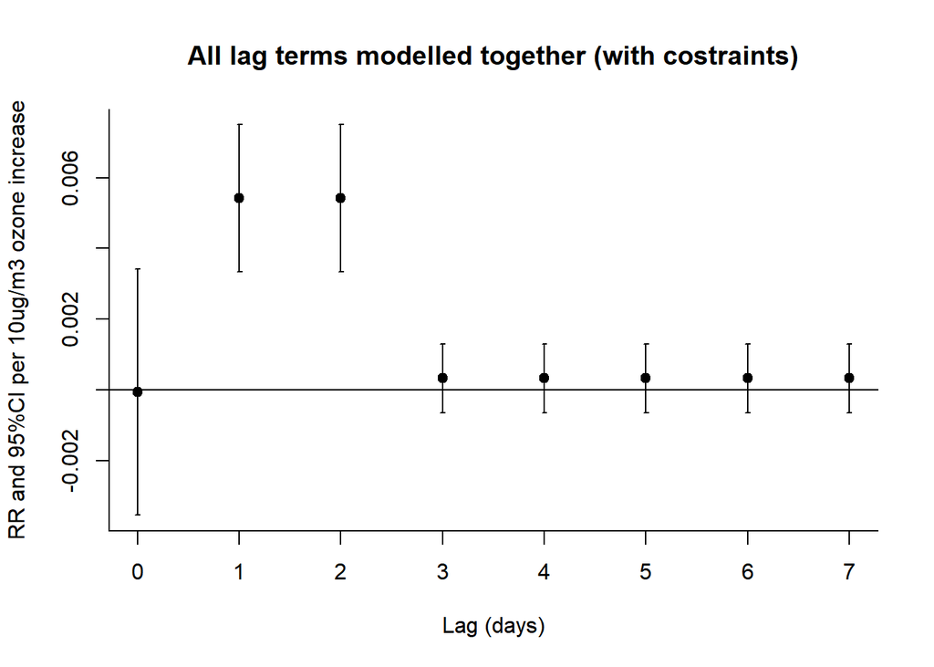

```r
plot(pred4_Ozone,var=10,type="p",ci="bars",col=1,pch=19,
     main="All lag terms modelled together (with costraints)",xlab="Lag (days)",
     ylab="RR and 95%CI per 10ug/m3 ozone increase")
```